# Biochemistry R Introduction Part 3

Ben Dickins and Callum Rimmer

2023-03-31

# Tutorial Part 3: Basic Linear Modelling

## Acknowledgment

The code from this section is mostly copied from [this book chapter](https://psyteachr.github.io/stat-models-v1/introducing-linear-mixed-effects-models.html) which itself is inspired by Richard McElreath’s excellent book [Statistical Rethinking](https://xcelab.net/rm/statistical-rethinking/) which I am studying presently. I will be making a few modifications over the next week. I apologise for missing this attribution in the initial version two days ago.

## Preparation

Here are the libraries we need for this part:

```r
library(tidyverse)
library(lme4)
```

The `lme4` library is a library for carrying out linear mixed modelling. Find out more with `?lme4`. Base R has a generalized linear modelling framework built-in, but mixed models are more often appropriate in biological sciences since individual organisms may frequently be expected to differ in baseline and response and can therefore considered to be picked from a distribution of possible states and plasticities in the population. The creators of `lme4` don’t like p values and neither do I, but we can show you methods for these if required.

## Step 1: Our Dataset

This one is a dataset from within the `lme4` library. I will explain a little about it, but let’s take a look also:

```r
data(sleepstudy)
?sleepstudy
sleepstudy %>% head()
```

```
##   Reaction Days Subject
## 1 249.5600    0     308
## 2 258.7047    1     308
## 3 250.8006    2     308
## 4 321.4398    3     308
## 5 356.8519    4     308
## 6 414.6901    5     308
```

Note that we had to use the `head()` function to show the first 6 rows of `sleepstudy`. The technical reason for this is that `sleepstudy` is not a tibble. It is a data frame and they don’t format prettily. Let’s use that `summary()` function again:

```r
summary(sleepstudy)
```

```
##     Reaction          Days        Subject
##  Min.   :194.3   Min.   :0.0   308    : 10
##  1st Qu.:255.4   1st Qu.:2.0   309    : 10
##  Median :288.7   Median :4.5   310    : 10
##  Mean   :298.5   Mean   :4.5   330    : 10
##  3rd Qu.:336.8   3rd Qu.:7.0   331    : 10
##  Max.   :466.4   Max.   :9.0   332    : 10
##                                (Other):120
```

Silly results so let’s fix that:

```r
( sleepTibble <- tibble(sleepstudy) )
```

```
## # A tibble: 180 × 3
##    Reaction  Days Subject
##       <dbl> <dbl> <fct>
##  1     250.     0 308
##  2     259.     1 308
##  3     251.     2 308
##  4     321.     3 308
##  5     357.     4 308
##  6     415.     5 308
##  7     382.     6 308
##  8     290.     7 308
##  9     431.     8 308
## 10     466.     9 308
## # ℹ 170 more rows
```

Note that the `tibble()` function has coerced the datatype for the `Subject` column to factors, and the other columns to “double” (high precision numeric). This is great (and again saves as from using additional `parse_*()` functions). We could also have typed `sleepTibble <- sleepstudy %>% tibble()` and I hope you noticed the outer brackets again!

## Step 2: Plot It!

Now we want to examine our data graphically and this will look familiar:

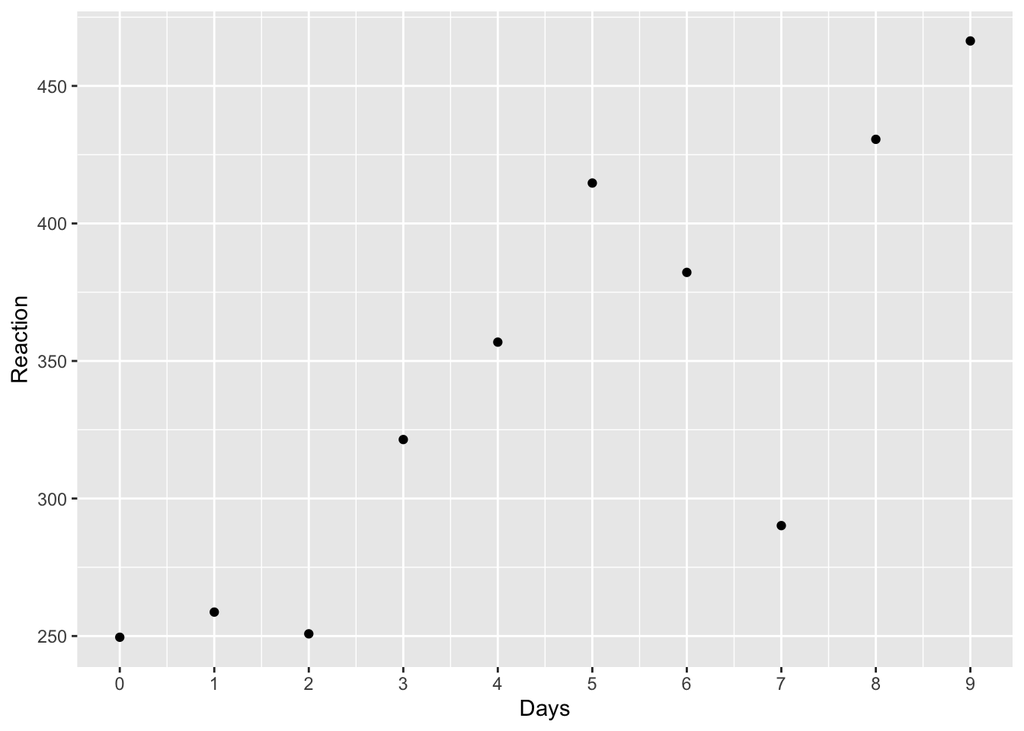

```r
sleepTibble %>%
  filter(Subject == "308") %>%
  ggplot(aes(x = Days, y = Reaction)) +
  geom_point() +
  scale_x_continuous(breaks = 0:9)
```

but notice how we piped directly into `ggplot()`, filtering on the fly. This is the power of the pipe. You build a pipeline, and your modifications to data are explicit. No more finding which was your original Excel spreadsheet (which, of course, is not good practice for reproducibility)!

Let’s do something to make plots look a bit different:

```r
old <- theme_set(theme_bw()) # show them theme setting
```

What is happening here is that the `theme_set()` is changing us to a new “black and white” setting (you’ll see the effects of this in a minute), but it also emits an output that corresponds to the current theme setting (before the change to black and white). This (old) setting is assigned to the object `old`. We will use that later.

For now let’s keep making graphs:

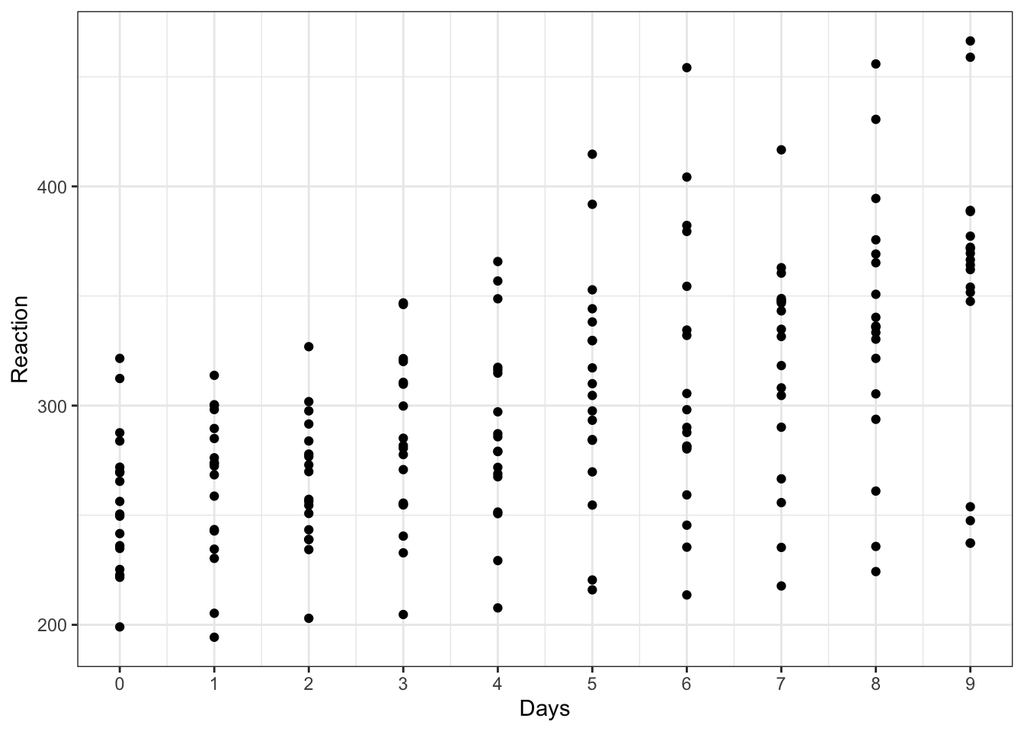

```r
ggplot(sleepTibble, aes(x = Days, y = Reaction)) +
  geom_point() +
  scale_x_continuous(breaks = 0:9)
```

Oh no, that’s hideous!

## Step 3: Facetting - Subplots for Free!

Why was the last graph so bad? Because of all that individual variation. You could just ignore that and use `geom_boxplot()`, but why not look at the subjects properly:

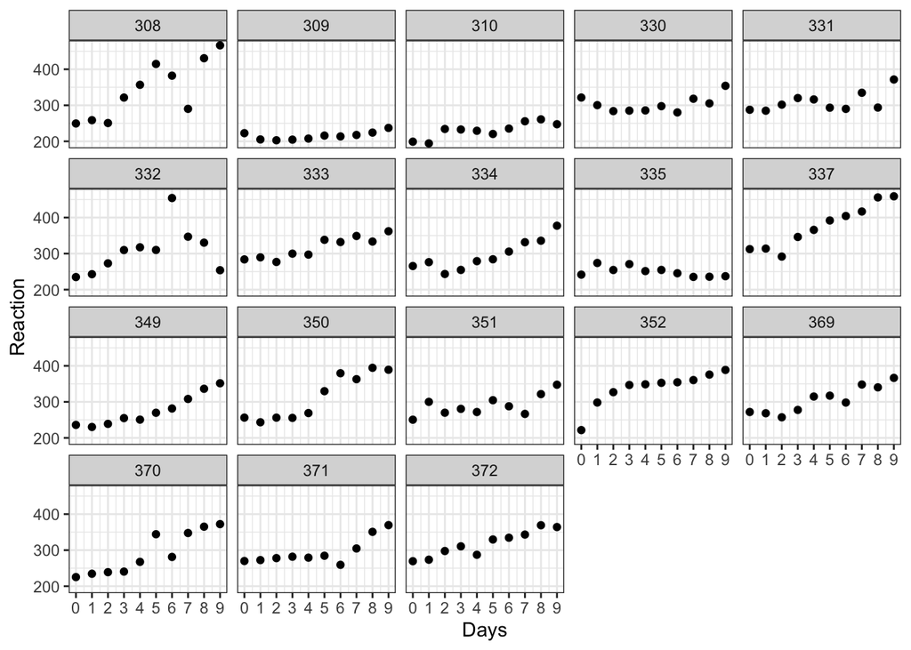

```r
ggplot(sleepTibble, aes(x = Days, y = Reaction)) +
  geom_point() +
  scale_x_continuous(breaks = 0:9) +
  facet_wrap(~Subject)
```

We made only one change: the `facet_wrap()` function (there is another function called `facet_grid()` which we can explain). These are important because they allow you to split an entire plot into subplots based on a variable. This is a killer app!

## Step 4: Some Data Processing

Now we are also able to see features of the time course. Now the study included a baseline period from days 0 to 1 (inclusive) with sleep deprivation only starying from day 2. See `?sleepstudy` for more details. So we need to filter our data:

```r
( sleepDeprived <- sleepTibble %>%
  filter(Days >= 2) %>%
  mutate(days_deprived = Days - 2) )
```

```
## # A tibble: 144 × 4
##    Reaction  Days Subject days_deprived
##       <dbl> <dbl> <fct>           <dbl>
##  1     251.     2 308                 0
##  2     321.     3 308                 1
##  3     357.     4 308                 2
##  4     415.     5 308                 3
##  5     382.     6 308                 4
##  6     290.     7 308                 5
##  7     431.     8 308                 6
##  8     466.     9 308                 7
##  9     203.     2 309                 0
## 10     205.     3 309                 1
## # ℹ 134 more rows
```

We filtered to keep only data from day 2 onwards and we calculated a new column in which day 2 is the new day 0, day 3 is day 1, etc. This new column is called `days_deprived`.

Let’s tally our data using the `count()` function we encountered in part 2:

```r
sleepDeprived %>% count(days_deprived, Days)
```

```
## # A tibble: 8 × 3
##   days_deprived  Days     n
##           <dbl> <dbl> <int>
## 1             0     2    18
## 2             1     3    18
## 3             2     4    18
## 4             3     5    18
## 5             4     6    18
## 6             5     7    18
## 7             6     8    18
## 8             7     9    18
```

## Step 5: Replotting

Let’s plot our data again:

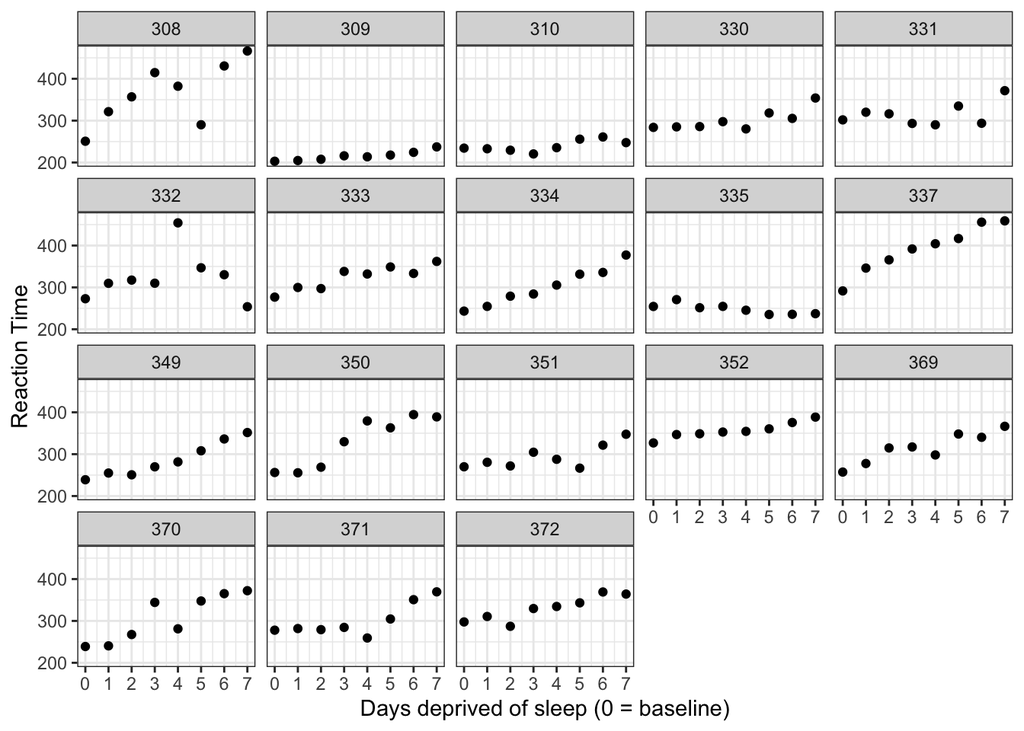

```r
ggplot(sleepDeprived, aes(x = days_deprived, y = Reaction)) +
  geom_point() +
  scale_x_continuous(breaks = 0:7) +
  facet_wrap(~Subject) +
  labs(y = "Reaction Time", x = "Days deprived of sleep (0 = baseline)")
```

## Step 6: Basic Linear Model

```r
cp_model <- lm(Reaction ~ days_deprived, sleepDeprived)
```

Summarise:

```r
summary(cp_model)
```

```
##
## Call:
## lm(formula = Reaction ~ days_deprived, data = sleepDeprived)
##
## Residuals:
##      Min       1Q   Median       3Q      Max
## -112.284  -26.732    2.143   27.734  140.453
##
## Coefficients:
##               Estimate Std. Error t value Pr(>|t|)
## (Intercept)    267.967      7.737  34.633  < 2e-16 ***
## days_deprived   11.435      1.850   6.183 6.32e-09 ***
## ---
## Signif. codes:  0 '***' 0.001 '**' 0.01 '*' 0.05 '.' 0.1 ' ' 1
##
## Residual standard error: 50.85 on 142 degrees of freedom
## Multiple R-squared:  0.2121, Adjusted R-squared:  0.2066
## F-statistic: 38.23 on 1 and 142 DF,  p-value: 6.316e-09
```

Wow that `summary()` function is handy. It’s the electric screwdriver of R.

extract the coefficients of the model:

```r
coef(cp_model)
```

```
##   (Intercept) days_deprived
##     267.96742      11.43543
```

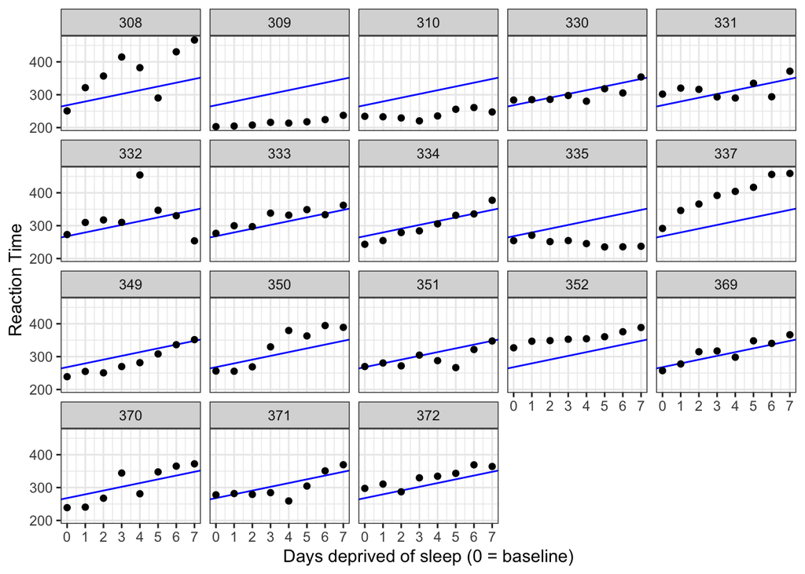

```r
ggplot(sleepDeprived, aes(x = days_deprived, y = Reaction)) +
  geom_abline(intercept = coef(cp_model)[1],
              slope = coef(cp_model)[2],
              color = 'blue') +
  geom_point() +
  scale_x_continuous(breaks = 0:7) +
  facet_wrap(~Subject) +
  labs(y = "Reaction Time", x = "Days deprived of sleep (0 = baseline)")
```

Now that is some serious plotting, but it turns out that a global linear model isn’t a good fit for each subject. Individual differences matter.

Add in “Subject” as a factor in the model (must be a factor variable - don’t ever do this if it is a numeric - your result will be absurd and you might not notice!):

```r
np_model <- lm(Reaction ~ days_deprived + Subject + days_deprived:Subject,
               data = sleepDeprived)

summary(np_model)
```

```
##
## Call:
## lm(formula = Reaction ~ days_deprived + Subject + days_deprived:Subject,
##     data = sleepDeprived)
##
## Residuals:
##      Min       1Q   Median       3Q      Max
## -106.521   -8.541    1.143    8.889  128.545
##
## Coefficients:
##                          Estimate Std. Error t value Pr(>|t|)
## (Intercept)              288.2175    16.4772  17.492  < 2e-16 ***
## days_deprived             21.6905     3.9388   5.507 2.49e-07 ***
## Subject309               -87.9262    23.3023  -3.773 0.000264 ***
## Subject310               -62.2856    23.3023  -2.673 0.008685 **
## Subject330               -14.9533    23.3023  -0.642 0.522422
## Subject331                 9.9658    23.3023   0.428 0.669740
## Subject332                27.8157    23.3023   1.194 0.235215
## Subject333                -2.7581    23.3023  -0.118 0.906000
## Subject334               -50.2051    23.3023  -2.155 0.033422 *
## Subject335               -25.3429    23.3023  -1.088 0.279207
## Subject337                24.6143    23.3023   1.056 0.293187
## Subject349               -59.2183    23.3023  -2.541 0.012464 *
## Subject350               -40.2023    23.3023  -1.725 0.087343 .
## Subject351               -24.2467    23.3023  -1.041 0.300419
## Subject352                43.0655    23.3023   1.848 0.067321 .
## Subject369               -21.5040    23.3023  -0.923 0.358154
## Subject370               -53.3072    23.3023  -2.288 0.024107 *
## Subject371               -30.4896    23.3023  -1.308 0.193504
## Subject372                 2.4772    23.3023   0.106 0.915535
## days_deprived:Subject309 -17.3334     5.5703  -3.112 0.002380 **
## days_deprived:Subject310 -17.7915     5.5703  -3.194 0.001839 **
## days_deprived:Subject330 -13.6849     5.5703  -2.457 0.015613 *
## days_deprived:Subject331 -16.8231     5.5703  -3.020 0.003154 **
## days_deprived:Subject332 -19.2947     5.5703  -3.464 0.000765 ***
## days_deprived:Subject333 -10.8151     5.5703  -1.942 0.054796 .
## days_deprived:Subject334  -3.5745     5.5703  -0.642 0.522423
## days_deprived:Subject335 -25.8995     5.5703  -4.650 9.47e-06 ***
## days_deprived:Subject337   0.7518     5.5703   0.135 0.892895
## days_deprived:Subject349  -5.2644     5.5703  -0.945 0.346731
## days_deprived:Subject350   1.6007     5.5703   0.287 0.774382
## days_deprived:Subject351 -13.1681     5.5703  -2.364 0.019867 *
## days_deprived:Subject352 -14.4019     5.5703  -2.585 0.011057 *
## days_deprived:Subject369  -7.8948     5.5703  -1.417 0.159273
## days_deprived:Subject370  -1.0495     5.5703  -0.188 0.850912
## days_deprived:Subject371  -9.3443     5.5703  -1.678 0.096334 .
## days_deprived:Subject372 -10.6041     5.5703  -1.904 0.059613 .
## ---
## Signif. codes:  0 '***' 0.001 '**' 0.01 '*' 0.05 '.' 0.1 ' ' 1
##
## Residual standard error: 25.53 on 108 degrees of freedom
## Multiple R-squared:  0.849,  Adjusted R-squared:  0.8001
## F-statistic: 17.35 on 35 and 108 DF,  p-value: < 2.2e-16
```

Jiggery-pokery:

```r
all_intercepts <- c(coef(np_model)["(Intercept)"],
                    coef(np_model)[3:19] + coef(np_model)["(Intercept)"])

all_slopes  <- c(coef(np_model)["days_deprived"],
                 coef(np_model)[20:36] + coef(np_model)["days_deprived"])

ids <- sleepDeprived %>% pull(Subject) %>% levels() %>% factor()
```

Make a tibble with the data extracted above:

```r
( np_coef <- tibble(Subject = ids,
                  intercept = all_intercepts,
                  slope = all_slopes) )
```

```
## # A tibble: 18 × 3
##    Subject intercept slope
##    <fct>       <dbl> <dbl>
##  1 308          288. 21.7
##  2 309          200.  4.36
##  3 310          226.  3.90
##  4 330          273.  8.01
##  5 331          298.  4.87
##  6 332          316.  2.40
##  7 333          285. 10.9
##  8 334          238. 18.1
##  9 335          263. -4.21
## 10 337          313. 22.4
## 11 349          229. 16.4
## 12 350          248. 23.3
## 13 351          264.  8.52
## 14 352          331.  7.29
## 15 369          267. 13.8
## 16 370          235. 20.6
## 17 371          258. 12.3
## 18 372          291. 11.1
```

Plot our new data as trend lines within broader plot:

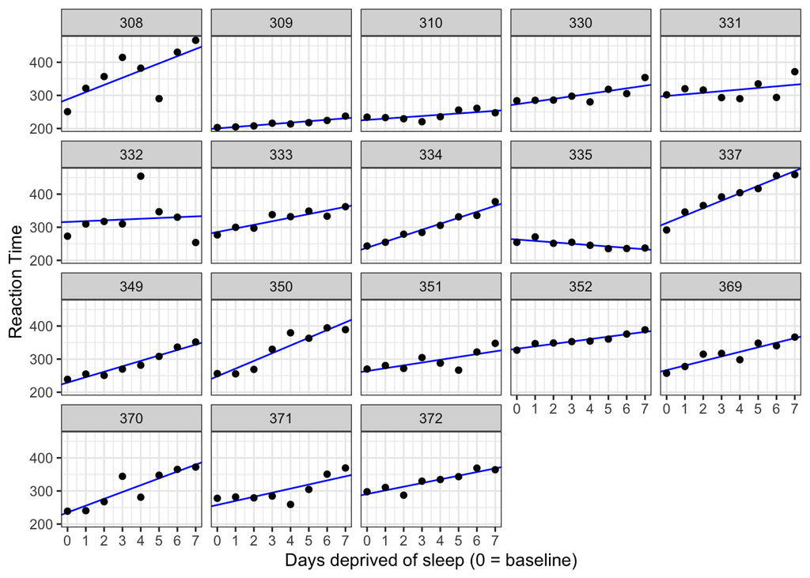

```r
ggplot(sleepDeprived, aes(x = days_deprived, y = Reaction)) +
  geom_abline(data = np_coef,
              mapping = aes(intercept = intercept,
                            slope = slope),
              color = 'blue') +
  geom_point() +
  scale_x_continuous(breaks = 0:7) +
  facet_wrap(~Subject) +
  labs(y = "Reaction Time", x = "Days deprived of sleep (0 = baseline)")
```

Do they differ significantly from a slope of zero:

```r
np_coef %>% pull(slope) %>% t.test()
```

```
##
##  One Sample t-test
##
## data:  .
## t = 6.1971, df = 17, p-value = 9.749e-06
## alternative hypothesis: true mean is not equal to 0
## 95 percent confidence interval:
##   7.542244 15.328613
## sample estimates:
## mean of x
##  11.43543
```

Yes!

## YIKES! Mixed Effects Model at Last:

```r
pp_mod <- lmer(Reaction ~ days_deprived + (days_deprived | Subject), sleepDeprived)

summary(pp_mod)
```

```
## Linear mixed model fit by REML ['lmerMod']
## Formula: Reaction ~ days_deprived + (days_deprived | Subject)
##    Data: sleepDeprived
##
## REML criterion at convergence: 1404.1
##
## Scaled residuals:
##     Min      1Q  Median      3Q     Max
## -4.0157 -0.3541  0.0069  0.4681  5.0732
##
## Random effects:
##  Groups   Name          Variance Std.Dev. Corr
##  Subject  (Intercept)   958.35   30.957
##           days_deprived  45.78    6.766   0.18
##  Residual               651.60   25.526
## Number of obs: 144, groups:  Subject, 18
##
## Fixed effects:
##               Estimate Std. Error t value
## (Intercept)    267.967      8.266  32.418
## days_deprived   11.435      1.845   6.197
##
## Correlation of Fixed Effects:
##             (Intr)
## days_deprvd -0.062
```

Explain the notation - brackets as random effects. Allows intercept and gradient to vary.

Jiggery-pokery:

```r
newdata <- crossing(
  Subject = sleepDeprived %>% pull(Subject) %>% levels() %>% factor(),
  days_deprived = 0:7)

head(newdata, 17)
```

```
## # A tibble: 17 × 2
##    Subject days_deprived
##    <fct>           <int>
##  1 308                 0
##  2 308                 1
##  3 308                 2
##  4 308                 3
##  5 308                 4
##  6 308                 5
##  7 308                 6
##  8 308                 7
##  9 309                 0
## 10 309                 1
## 11 309                 2
## 12 309                 3
## 13 309                 4
## 14 309                 5
## 15 309                 6
## 16 309                 7
## 17 310                 0
```

```r
newdata2 <- newdata %>%
  mutate(Reaction = predict(pp_mod, newdata))
```

Plot again with mixed model gradients:

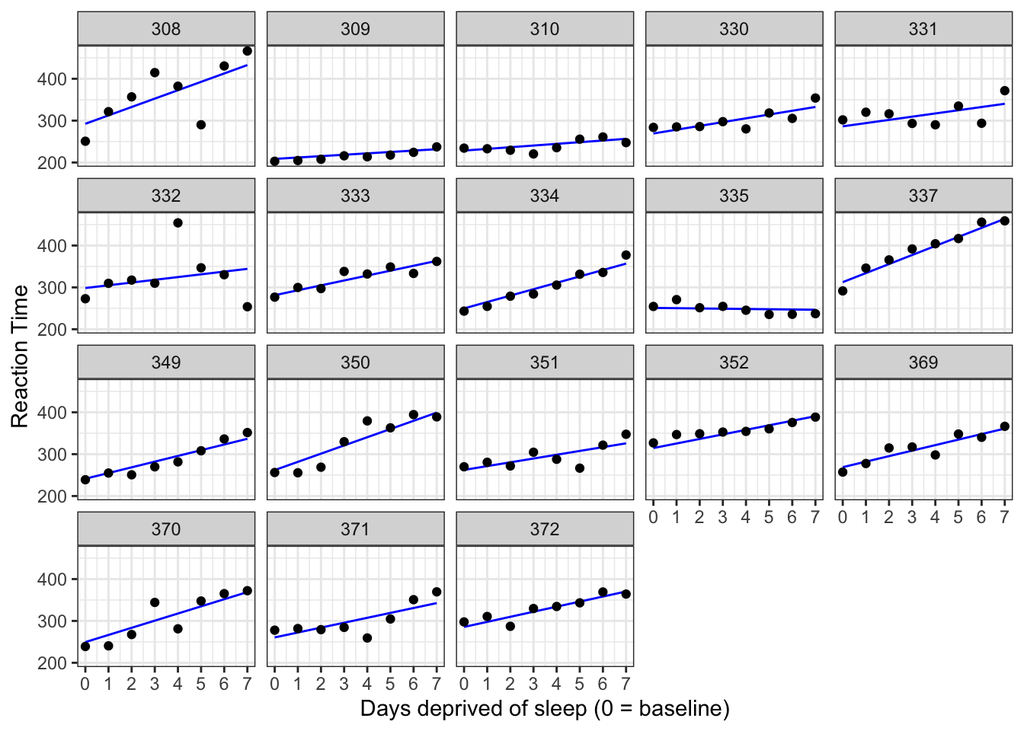

```r
ggplot(sleepDeprived, aes(x = days_deprived, y = Reaction)) +
  geom_line(data = newdata2,
            color = 'blue') +
  geom_point() +
  scale_x_continuous(breaks = 0:7) +
  facet_wrap(~Subject) +
  labs(y = "Reaction Time", x = "Days deprived of sleep (0 = baseline)")
```

Get info on our fixed effects’ coefficients (the ones of interest):

```r
fixef(pp_mod)
```

```
##   (Intercept) days_deprived
##     267.96742      11.43543
```

OK - too detailed here:

```r
# standard error of fixed effects
vcov(pp_mod) %>% diag() %>% sqrt()
```

```
##   (Intercept) days_deprived
##      8.265896      1.845293
```

```r
tvals <- fixef(pp_mod) / sqrt(diag(vcov(pp_mod)))
tvals
```

```
##   (Intercept) days_deprived
##     32.418437      6.197082
```

```r
2 * (1 - pnorm(abs(tvals)))
```

```
##   (Intercept) days_deprived
##   0.00000e+00   5.75197e-10
```

```r
confint(pp_mod)
```

```
## Computing profile confidence intervals ...
```

```
##                     2.5 %      97.5 %
## .sig01         19.0980993  46.3366669
## .sig02         -0.4051075   0.8059258
## .sig03          4.0079284  10.2487353
## .sigma         22.4666029  29.3494508
## (Intercept)   251.3443396 284.5904989
## days_deprived   7.7245247  15.1463328
```

```r
# random effects
sigma(pp_mod) # residual
```

```
## [1] 25.5264
```

```r
# variance-covariance matrix for random factor Subject
VarCorr(pp_mod)[["Subject"]] # equivalently: VarCorr(pp_mod)[[1]]
```

```
##               (Intercept) days_deprived
## (Intercept)      958.3517      37.20460
## days_deprived     37.2046      45.77766
## attr(,"stddev")
##   (Intercept) days_deprived
##     30.957255      6.765919
## attr(,"correlation")
##               (Intercept) days_deprived
## (Intercept)     1.0000000     0.1776263
## days_deprived   0.1776263     1.0000000
```

Revert plotting behaviour:

```r
theme_set(old)
```

The End!